# Module 2 Individual Assignment

Bryan Yang

2022-09-16

1a. Using the dataset we cleaned up and used in class (called “…EPS rounding_after class” and provided for you as well as the data description sheet, “…Data Description Sheet_EPS rounding_after class.xlsx”), graph a bar chart that shows separate plots for the frequency of the EPS digit after the decimal point (called “digit_diluted” in the dataset) based upon the quarters of the year (1-4). Thus, you will have four separate plots or one plot with 4 separate panels or facets. Hint: We did this in class but had a separate plot for each year instead of for each quarter. For R, use `facet_wrap()`.

```r
# Step 1: Bring in and explore data
library(tidyverse)
df1 <- read_rds("assign_data_EPS rounding_after class.rds")
head(df1, 10)
```

```
## # A tibble: 10 × 10
##    tic   conm     fyearq  fqtr curcdq ibadjq xidoq cshfdq EPS_diluted_…¹ digit…²
##    <chr> <chr>     <dbl> <dbl> <chr>   <dbl> <dbl>  <dbl>          <dbl> <chr>
##  1 AIR   AAR CORP   1998     3 USD     10.3      0   28.0          36.8  7
##  2 AIR   AAR CORP   1998     4 USD     11.7      0   27.7          42.4  3
##  3 AIR   AAR CORP   1999     1 USD     10.8      0   27.8          38.9  9
##  4 AIR   AAR CORP   1999     2 USD     10.9      0   27.5          39.7  6
##  5 AIR   AAR CORP   1999     3 USD     11.0      0   27.3          40.2  1
##  6 AIR   AAR CORP   1999     4 USD      2.47     0   27.1           9.11 1
##  7 AIR   AAR CORP   2000     1 USD      3.16     0   27.0          11.7  7
##  8 AIR   AAR CORP   2000     2 USD      4.28     0   27.0          15.9  8
##  9 AIR   AAR CORP   2000     3 USD      5.39     0   27.1          19.9  9
## 10 AIR   AAR CORP   2000     4 USD      5.71     0   27.0          21.1  1
## # … with abbreviated variable names ¹EPS_diluted_cents, ²digit_diluted
```

```r
str(df1)
```

```
## tibble [384,308 × 10] (S3: tbl_df/tbl/data.frame)
##  $ tic              : chr [1:384308] "AIR" "AIR" "AIR" "AIR" ...
##   ..- attr(*, "label")= chr "Ticker Symbol"
##   ..- attr(*, "format.sas")= chr "$"
##  $ conm             : chr [1:384308] "AAR CORP" "AAR CORP" "AAR CORP" "AAR CORP" ...
##   ..- attr(*, "label")= chr "Company Name"
##   ..- attr(*, "format.sas")= chr "$"
##  $ fyearq           : num [1:384308] 1998 1998 1999 1999 1999 ...
##   ..- attr(*, "label")= chr "Fiscal Year"
##   ..- attr(*, "format.sas")= chr "F"
##  $ fqtr             : num [1:384308] 3 4 1 2 3 4 1 2 3 4 ...
##   ..- attr(*, "label")= chr "Fiscal Quarter"
##   ..- attr(*, "format.sas")= chr "F"
##  $ curcdq           : chr [1:384308] "USD" "USD" "USD" "USD" ...
##   ..- attr(*, "label")= chr "ISO Currency Code"
##   ..- attr(*, "format.sas")= chr "$"
##  $ ibadjq           : num [1:384308] 10.3 11.7 10.8 10.9 11 ...
##   ..- attr(*, "label")= chr "Income Before Extraordinary Items - Adjusted for Common Stock Equivalents"
##   ..- attr(*, "format.sas")= chr "F"
##  $ xidoq            : num [1:384308] 0 0 0 0 0 0 0 0 0 0 ...
##   ..- attr(*, "label")= chr "Extraordinary Items and Discontinued Operations"
##   ..- attr(*, "format.sas")= chr "F"
##  $ cshfdq           : num [1:384308] 28 27.7 27.8 27.5 27.3 ...
##   ..- attr(*, "label")= chr "Com Shares for Diluted EPS"
##   ..- attr(*, "format.sas")= chr "F"
##  $ EPS_diluted_cents: num [1:384308] 36.8 42.4 38.9 39.7 40.2 ...
##   ..- attr(*, "label")= chr "Income Before Extraordinary Items - Adjusted for Common Stock Equivalents"
##   ..- attr(*, "format.sas")= chr "F"
##  $ digit_diluted    : chr [1:384308] "7" "3" "9" "6" ...
##  - attr(*, "label")= chr "Merged Fundamental Quarterly File"
```

```r
# Step 2: Calculate diluted EPS in cents
# 100 * (income after extraordinary items ('IBADJQ' + 'XIDOQ')) / number of common shares used to calculate diluted EPS ('CSJFDQ')
df1 <- df1 %>%
  mutate(EPS_diluted_cents = ((ibadjq + xidoq) * 100) / cshfdq)

# Step 3: Extract the digit
# 'stringr::str_sub()' is a tidyverse function that extracts substrings from text
#       start and end points are inclusive
# 'stringr::str_locate()' is a tidyverse function that locates a substring in text
# '\\.' is regular expression code to find the decimal point

df1 <- df1 %>%
  mutate(digit_diluted = stringr::str_sub(as.character(EPS_diluted_cents),
                                          start = stringr::str_locate(as.character(EPS_diluted_cents), '\\.') +1,
                                          end = stringr::str_locate(as.character(EPS_diluted_cents), '\\.') +1))

# Step 4: Keep EPS > 0.1
df1 <- df1 %>%
  filter(EPS_diluted_cents > 0.1)

# Step 5: Group by year, quarter, and digit and then count occurrences
df2 <- df1 %>%
  group_by(fyearq, fqtr, digit_diluted) %>%
  summarize(count_filings = n())
```

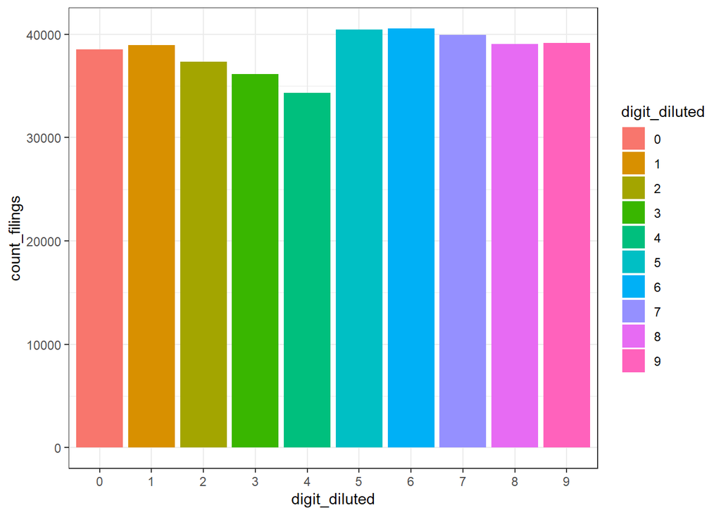

```r
# Step 6: Plot the counts by digit
df2 %>%
  ggplot(aes(x = digit_diluted, y = count_filings)) +
  geom_col(aes(fill = digit_diluted)) + theme_bw()
```

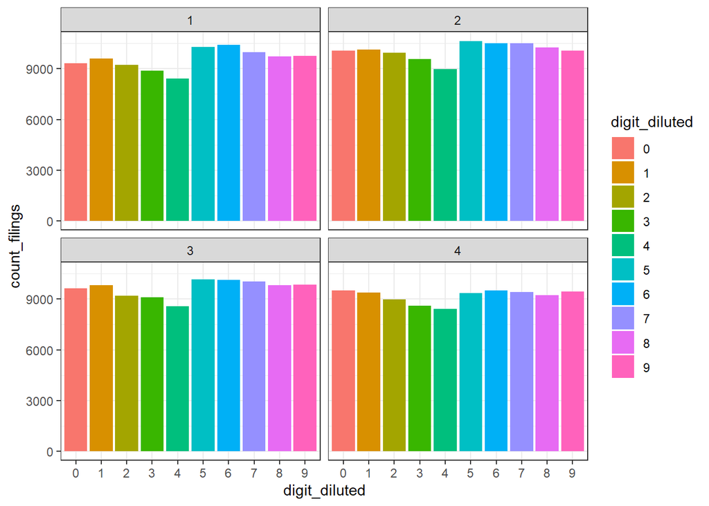

```r
# Step 7: Separate plots by quarters
df2 %>%
  ggplot(aes(x = digit_diluted, y = count_filings)) +
  geom_col(aes(fill = digit_diluted)) +
  facet_wrap(vars(as_factor(fqtr))) + theme_bw()
```

1b. Which quarter or quarters have the smallest difference in the frequency of integer 4 relative to integer 5? You don’t need to calculate this difference, just look at the four plots and make your best judgment.

**Quarter 4 seems to have the smallest difference in the frequency of integer 4 relative to integer 5.**

2a. Next, create and examine these same sets of plots for just 1998. Thus, you will have four sets of graphs for that year.

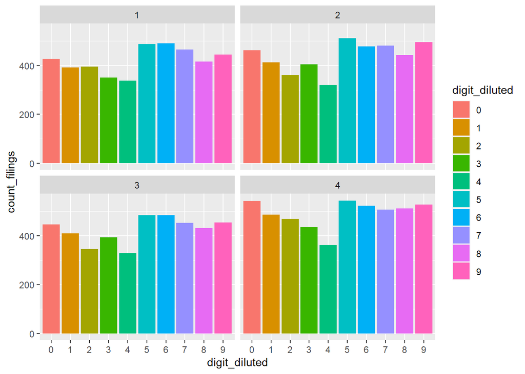

```r
df3 <- df2 %>%
  filter(fyearq == 1998)
df3 %>%
  ggplot(aes(x = digit_diluted, y = count_filings)) +
  geom_col(aes(fill = digit_diluted)) +
  facet_wrap(vars(as_factor(fqtr)))
```

**The differences in the frequency of the integer 4 and 5 are more noticeable in each quarter for 1998 than the aggregated data graph from 1998 to 2020.**

2b. Next, create and examine this same set of plots for just 2019. Thus, you will have four sets of graphs for that year.

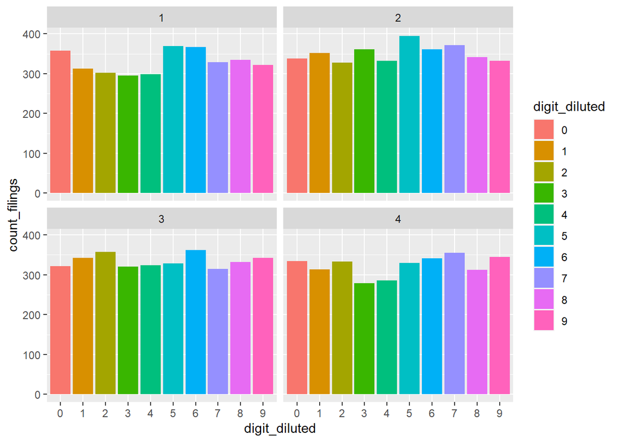

```r
df4 <- df2 %>%
  filter(fyearq == 2019)
df4 %>%
  ggplot(aes(x = digit_diluted, y = count_filings)) +
  geom_col(aes(fill = digit_diluted)) +
  facet_wrap(vars(as_factor(fqtr)))
```

**The differences in the frequency of the integer 4 and 5 are very similar for quarter 1 and 2 for 2019 to the aggregated data graph from 1998 to 2020. However, there are very small difference in the frequency of the integer 4 and 5 for 2019.**

2c. What differences do you notice between 1998 and 2019 in the frequency of integer 4 and the frequency of integer 4 relative to integer 5?

3. Next, use your analytics skills to find and report the worst 10 offenders of EPS rounding to the SEC.
- Specifically, create a table of the 10 worst offenders following the criteria _below.
- You will need to create a table that has one observation per company. Thus, you will need to aggregate each company’s results down to one row using a summarize function.
- Additionally, you will only include a company in the table if the aggregated results from that company meet the following criteria:
  - The company has more than 56 observations (quarters/rows) in the original, “EPS rounding_after class,” dataset.
  - Less than 1.18% of all of the company’s observations have a 4 in the digit after the decimal point of EPS (e.g., in the `EPS_diluted_cents` column).
  - More than 11% of all of the company’s observations have a 5 in the digit after the decimal point of EPS (e.g., in the `EPS_diluted_cents` column).

```r
# Create columns for 4 & 5 in the digit after decimal point of EPS in TRUE or FALSE
df5 <- df1 %>%
  mutate(
    EPS_digit_4 = digit_diluted == 4,
    EPS_digit_5 = digit_diluted == 5
  )

# Convert columns for 4 & 5 in the digit after decimal point of EPS to 1 or 0
df5$EPS_digit_4 <- ifelse(df5$EPS_digit_4 == TRUE, 1, 0)
df5$EPS_digit_5 <- ifelse(df5$EPS_digit_5 == TRUE, 1, 0)
```

```r
# Aggregate the dataframe in company per row
df5 <- df5 %>%
  select(tic, conm, EPS_digit_4, EPS_digit_5) %>%
  group_by(tic, conm) %>%
  summarize(
            EPS_digit_4 = sum(EPS_digit_4),
            EPS_digit_5 = sum(EPS_digit_5),
            total_obs = n()
            ) %>%
  ungroup()
```

[output not shown]

```r
# Create columns for 4 & 5 in the digit percentage to the total observations per company
df5 <- df5 %>%
  mutate(
    EPS_digit_4_per = round(EPS_digit_4 / total_obs, digits = 4),
    EPS_digit_5_per = round(EPS_digit_5 / total_obs, digits = 4)
  )
```

```r
# Filter based on the criteria above
df5 <- df5 %>%
  filter(
    # More than 56 observatons (quarters/rows)
    total_obs > 56,
    # Less than 1.18% of all of the company's observations have a 4 in the digit after the decimal point of EPS
    EPS_digit_4_per < .0118,
    # More than 11% of all of the company's observations have a 5 in the digit after the decimal point of EPS
    EPS_digit_5_per > .11
    )
```

3a. Submit this table. At the minimum, the table (or a screenshot of the table) must contain the ticker (tic), company name (conm), percentages of observations with 4 in the first digit after the decimal, and percentages of observations with 5 in the first digit after the decimal._

```r
# Show table of the 10 worst offenders following the criteria above
df5[1:10,]
```

```
## # A tibble: 10 × 7
##    tic   conm                       EPS_digit_4 EPS_di…¹ total…² EPS_d…³ EPS_d…⁴
##    <chr> <chr>                            <dbl>    <dbl>   <int>   <dbl>   <dbl>
##  1 ABAX  ABAXIS INC                           0       11      68  0        0.162
##  2 FEIM  FREQUENCY ELECTRONICS INC            0        9      58  0        0.155
##  3 FNLC  FIRST BANCORP INC/ME                 1       13      87  0.0115   0.149
##  4 FULT  FULTON FINANCIAL CORP                1       13      90  0.0111   0.144
##  5 FWRD  FORWARD AIR CORP                     1       18      86  0.0116   0.209
##  6 MCRL  MICREL INC                           0        9      61  0        0.148
##  7 NUS   NU SKIN ENTERPRISES  -CL A           1       14      89  0.0112   0.157
##  8 TILE  INTERFACE INC                        0       19      65  0        0.292
##  9 TTEK  TETRA TECH INC                       1       14      86  0.0116   0.163
## 10 <NA>  <NA>                                NA       NA      NA NA       NA
## # … with abbreviated variable names ¹EPS_digit_5, ²total_obs, ³EPS_digit_4_per,
## #   ⁴EPS_digit_5_per
```

3b. What observations can you make about these companies?_

3c. Are the three companies charged by the SEC (FULT, HCSG, and TILE) in the following article in your table? A simple “yes” or “no” is fine. You do not have to answer this question. We will not grade your 3c._

**Yes, out of three (FULT, HCSG, TILE), we can see FULT & TILE.**